# Linear_Regression Explained

Matthew Davis

September 24, 2018

### Basic Concept

#### Why Linear Regression

- explainablity
- causaulity if and only if results are randomized trails
- magnitude of influence and standard error each variable
- considered gold standard in many fields
- significant p-values can turn into published papers
- computationally simply
- scalable when using gradient descent

#### draw backs

- requires careful setup
- influenced in training and scoring by outliers
- not very powerful compaired to other methods
- assumptions are required are often limiting
- very easy to do poorly

linear regression is try to fit a line throught a points of data. There are many types of linear regression, but tyically OLS (ordinary least squares) is used for smaller data sets, a gradient descent regression for massive data sets. Regression has assumptions that need to be true to also make conclusions draw from regression appropriated.

http://people.duke.edu/~rnau/testing.htm

#### Assumptions of Linear Regressioin

- linearity and additivity of the relationship between dependent and independent variables:
- cannot have large correlations between variables
- relationships must fundamentally be linear
- statistical independence of the errors (in particular, no correlation between consecutive errors in the case of time series data)
- a set of data points cannot be influenced by any other set of data points.
- homoscedasticity (constant variance) of the errors
- variables have the same variance allong their sequences. (example age vs income, folks in their 40s have a much hier variance in income than people in their teens, this would fail the assumption)
- normality of the error distribution.
- preds - actuals must be normally distributed with mean zero.
  - This can be tested with shapiro test for normallity if required
- Finally, linear regression analysis may be heaviliy influence by outliers.
- post plotting using cooks distance and influence can be used in most cases to identify

### how R solves linear regression via OLS matrix method

https://web.stanford.edu/~mrosenfe/soc_meth_proj3/matrix_OLS_NYU_notes.pdf

### How this method is typically done at scale using gradient descent

https://machinelearningmastery.com/gradient-descent-for-machine-learning/

### Setting up regression (for small data sets)

- need 30+ data pints
- look at distrobutions
- look at correlations
- build and test a model, remove outliers if nessicary
- y = mx + b
- b is the value of y when x = 0
- m is the addative difference in y with an increase of 1 in x

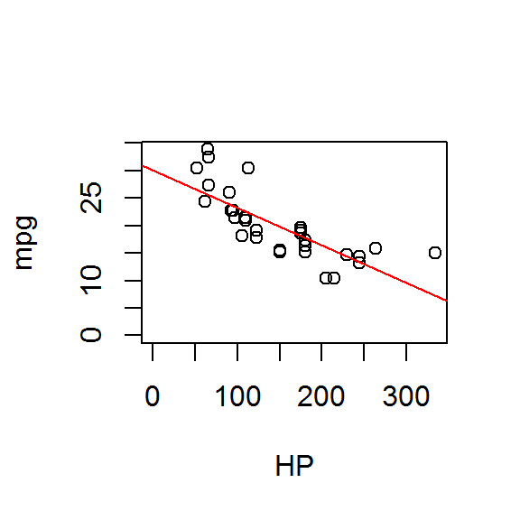

```r
data(mtcars)
d = mtcars
plot(d$hp, d$mpg, xlim=c(0, max(d$hp)), ylim = c(0, max(d$mpg)), xlab='HP', ylab='mpg')
f <- formula(mpg~hp)
fit<-lm(f, d)
abline(fit$coeff, col = 'red')
```

```r
summary(fit)
```

```
##
## Call:
## lm(formula = f, data = d)
##
## Residuals:
##     Min      1Q  Median      3Q     Max
## -5.7121 -2.1122 -0.8854  1.5819  8.2360
##
## Coefficients:
##             Estimate Std. Error t value Pr(>|t|)
## (Intercept) 30.09886    1.63392  18.421  < 2e-16 ***
## hp          -0.06823    0.01012  -6.742 1.79e-07 ***
## ---
## Signif. codes:  0 '***' 0.001 '**' 0.01 '*' 0.05 '.' 0.1 ' ' 1
##
## Residual standard error: 3.863 on 30 degrees of freedom
## Multiple R-squared:  0.6024, Adjusted R-squared:  0.5892
## F-statistic: 45.46 on 1 and 30 DF,  p-value: 1.788e-07
```

With factor variables

```r
d = mtcars
f <- formula(mpg~as.factor(am))
fit<-lm(f, d)
summary(fit)
```

```
##
## Call:
## lm(formula = f, data = d)
##
## Residuals:
##     Min      1Q  Median      3Q     Max
## -9.3923 -3.0923 -0.2974  3.2439  9.5077
##
## Coefficients:
##                Estimate Std. Error t value Pr(>|t|)
## (Intercept)      17.147      1.125  15.247 1.13e-15 ***
## as.factor(am)1    7.245      1.764   4.106 0.000285 ***
## ---
## Signif. codes:  0 '***' 0.001 '**' 0.01 '*' 0.05 '.' 0.1 ' ' 1
##
## Residual standard error: 4.902 on 30 degrees of freedom
## Multiple R-squared:  0.3598, Adjusted R-squared:  0.3385
## F-statistic: 16.86 on 1 and 30 DF,  p-value: 0.000285
```

```r
# the intercept
b = mean(d[d$am == 0, 'mpg'])
print(paste('the intercept: ', b))
```

```
## [1] "the intercept:  17.1473684210526"
```

```r
m = mean(d[d$am == 1, 'mpg']) - b
print(paste('the slope: ', m))
```

```
## [1] "the slope:  7.24493927125506"
```

[output not shown]